# Risk Factor Analysis

## Outcome Variable

**Outcome Variable:** sstunted

## Predictor Variables

**Intervention Variable:** nrooms

**Adjustment Set:**

unadjusted

## Stratifying Variables

The analysis was stratified on these variable(s):

- agecat
- studyid

The following strata were considered:

- agecat: 12 months, studyid: ki0047075b-MAL-ED
- agecat: 12 months, studyid: ki1000108-CMC-V-BCS-2002
- agecat: 12 months, studyid: ki1000108-IRC
- agecat: 12 months, studyid: ki1017093b-PROVIDE
- agecat: 12 months, studyid: ki1017093c-NIH-Crypto
- agecat: 12 months, studyid: ki1113344-GMS-Nepal
- agecat: 12 months, studyid: ki1114097-CONTENT
- agecat: 12 months, studyid: ki1135781-COHORTS
- agecat: 18 months, studyid: ki0047075b-MAL-ED
- agecat: 18 months, studyid: ki1000108-CMC-V-BCS-2002
- agecat: 18 months, studyid: ki1000108-IRC
- agecat: 18 months, studyid: ki1017093b-PROVIDE
- agecat: 18 months, studyid: ki1017093c-NIH-Crypto
- agecat: 18 months, studyid: ki1113344-GMS-Nepal
- agecat: 18 months, studyid: ki1114097-CONTENT
- agecat: 24 months, studyid: ki0047075b-MAL-ED
- agecat: 24 months, studyid: ki1000108-CMC-V-BCS-2002
- agecat: 24 months, studyid: ki1000108-IRC
- agecat: 24 months, studyid: ki1017093b-PROVIDE
- agecat: 24 months, studyid: ki1017093c-NIH-Crypto
- agecat: 24 months, studyid: ki1113344-GMS-Nepal
- agecat: 24 months, studyid: ki1114097-CONTENT
- agecat: 24 months, studyid: ki1135781-COHORTS
- agecat: 3 months, studyid: ki0047075b-MAL-ED
- agecat: 3 months, studyid: ki1000108-CMC-V-BCS-2002
- agecat: 3 months, studyid: ki1000108-IRC
- agecat: 3 months, studyid: ki1017093b-PROVIDE
- agecat: 3 months, studyid: ki1017093c-NIH-Crypto
- agecat: 3 months, studyid: ki1113344-GMS-Nepal
- agecat: 3 months, studyid: ki1114097-CONTENT
- agecat: 3 months, studyid: ki1135781-COHORTS
- agecat: 6 months, studyid: ki0047075b-MAL-ED
- agecat: 6 months, studyid: ki1000108-CMC-V-BCS-2002
- agecat: 6 months, studyid: ki1000108-IRC
- agecat: 6 months, studyid: ki1017093b-PROVIDE
- agecat: 6 months, studyid: ki1017093c-NIH-Crypto
- agecat: 6 months, studyid: ki1113344-GMS-Nepal
- agecat: 6 months, studyid: ki1114097-CONTENT
- agecat: 6 months, studyid: ki1135781-COHORTS
- agecat: 9 months, studyid: ki0047075b-MAL-ED
- agecat: 9 months, studyid: ki1000108-CMC-V-BCS-2002
- agecat: 9 months, studyid: ki1000108-IRC
- agecat: 9 months, studyid: ki1017093b-PROVIDE
- agecat: 9 months, studyid: ki1017093c-NIH-Crypto
- agecat: 9 months, studyid: ki1113344-GMS-Nepal
- agecat: 9 months, studyid: ki1114097-CONTENT
- agecat: 9 months, studyid: ki1135781-COHORTS
- agecat: Birth, studyid: ki0047075b-MAL-ED
- agecat: Birth, studyid: ki1000108-CMC-V-BCS-2002
- agecat: Birth, studyid: ki1000108-IRC
- agecat: Birth, studyid: ki1017093c-NIH-Crypto
- agecat: Birth, studyid: ki1114097-CONTENT
- agecat: Birth, studyid: ki1135781-COHORTS

### Dropped Strata

Some strata were dropped due to rare outcomes:

- agecat: Birth, studyid: ki1000108-CMC-V-BCS-2002
- agecat: Birth, studyid: ki1000108-IRC
- agecat: Birth, studyid: ki1017093c-NIH-Crypto
- agecat: Birth, studyid: ki1114097-CONTENT
- agecat: Birth, studyid: ki1135781-COHORTS
- agecat: 3 months, studyid: ki1000108-CMC-V-BCS-2002
- agecat: 3 months, studyid: ki1000108-IRC
- agecat: 3 months, studyid: ki1017093b-PROVIDE
- agecat: 3 months, studyid: ki1017093c-NIH-Crypto
- agecat: 3 months, studyid: ki1113344-GMS-Nepal
- agecat: 3 months, studyid: ki1114097-CONTENT
- agecat: 3 months, studyid: ki1135781-COHORTS
- agecat: 6 months, studyid: ki1000108-CMC-V-BCS-2002
- agecat: 6 months, studyid: ki1000108-IRC
- agecat: 6 months, studyid: ki1017093b-PROVIDE
- agecat: 6 months, studyid: ki1017093c-NIH-Crypto
- agecat: 6 months, studyid: ki1113344-GMS-Nepal
- agecat: 6 months, studyid: ki1114097-CONTENT
- agecat: 6 months, studyid: ki1135781-COHORTS
- agecat: 9 months, studyid: ki1000108-CMC-V-BCS-2002
- agecat: 9 months, studyid: ki1000108-IRC
- agecat: 9 months, studyid: ki1017093b-PROVIDE
- agecat: 9 months, studyid: ki1017093c-NIH-Crypto
- agecat: 9 months, studyid: ki1113344-GMS-Nepal
- agecat: 9 months, studyid: ki1114097-CONTENT
- agecat: 9 months, studyid: ki1135781-COHORTS
- agecat: 12 months, studyid: ki1000108-CMC-V-BCS-2002
- agecat: 12 months, studyid: ki1000108-IRC
- agecat: 12 months, studyid: ki1017093b-PROVIDE
- agecat: 12 months, studyid: ki1017093c-NIH-Crypto
- agecat: 12 months, studyid: ki1114097-CONTENT
- agecat: 12 months, studyid: ki1135781-COHORTS
- agecat: 18 months, studyid: ki1000108-CMC-V-BCS-2002
- agecat: 18 months, studyid: ki1000108-IRC
- agecat: 18 months, studyid: ki1017093b-PROVIDE
- agecat: 18 months, studyid: ki1017093c-NIH-Crypto
- agecat: 18 months, studyid: ki1114097-CONTENT
- agecat: 24 months, studyid: ki1000108-CMC-V-BCS-2002
- agecat: 24 months, studyid: ki1000108-IRC
- agecat: 24 months, studyid: ki1017093b-PROVIDE
- agecat: 24 months, studyid: ki1017093c-NIH-Crypto
- agecat: 24 months, studyid: ki1114097-CONTENT
- agecat: 24 months, studyid: ki1135781-COHORTS

## Methods Detail

We’re interested in the causal parameters $E[Y_a]$ for all values of $a \in \mathcal{A}$. These parameters represent the mean outcome if, possibly contrary to fact, we intervened to set all units to have $A=a$. Under the randomization and positivity assumptions, these are identified by the statistical parameters $\psi_a=E_W[E_{Y|A,W}(Y|A=a,W)]$. In addition, we’re interested in the mean of $Y$, $E[Y]$ under no intervention (the observed mean). We will estimate these parameters by using SuperLearner to fit the relevant likelihood factors – $E_{Y|A,W}(Y|A=a,W)$ and $p(A=a|W)$, and then updating our likelihood fit using a joint TMLE.

For unadjusted analyses ($W=\{\}$), initial likelihoods were estimated using Lrnr_glm to estimate the simple $E(Y|A)$ and Lrnr_mean to estimate $p(A)$. For adjusted analyses, a small library containing Lrnr_glmnet, Lrnr_xgboost, and Lrnr_mean was used.

Having estimated these parameters, we will then use the delta method to estimate relative risks and attributable risks relative to a prespecified baseline level of $A$.

# Results Detail

## Results Plots

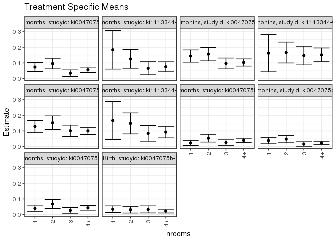

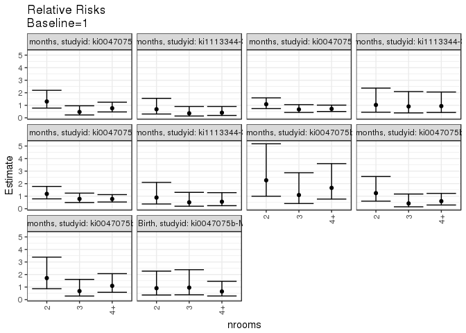

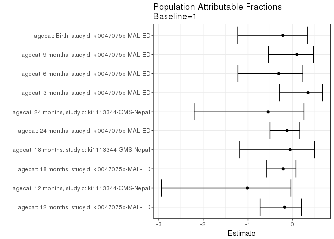

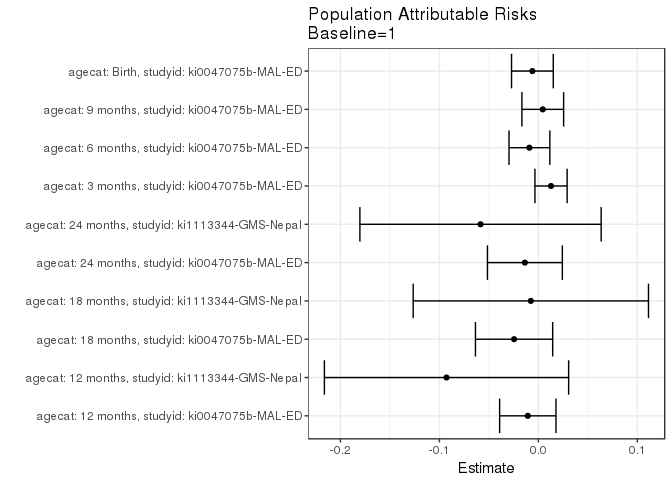

## Data Summary

| agecat | studyid | A | n | nA | nAY0 | nAY1 |
| --- | --- | --- | --- | --- | --- | --- |
| Birth | ki0047075b-MAL-ED | 1 | 1365 | 289 | 279 | 10 |
| Birth | ki0047075b-MAL-ED | 2 | 1365 | 254 | 246 | 8 |
| Birth | ki0047075b-MAL-ED | 3 | 1365 | 242 | 234 | 8 |
| Birth | ki0047075b-MAL-ED | 4+ | 1365 | 580 | 567 | 13 |
| Birth | ki1000108-CMC-V-BCS-2002 | 1 | 90 | 38 | 36 | 2 |
| Birth | ki1000108-CMC-V-BCS-2002 | 2 | 90 | 28 | 28 | 0 |
| Birth | ki1000108-CMC-V-BCS-2002 | 3 | 90 | 19 | 18 | 1 |
| Birth | ki1000108-CMC-V-BCS-2002 | 4+ | 90 | 5 | 5 | 0 |
| Birth | ki1000108-IRC | 1 | 386 | 175 | 167 | 8 |
| Birth | ki1000108-IRC | 2 | 386 | 161 | 153 | 8 |
| Birth | ki1000108-IRC | 3 | 386 | 33 | 33 | 0 |
| Birth | ki1000108-IRC | 4+ | 386 | 17 | 17 | 0 |
| Birth | ki1017093b-PROVIDE | 1 | 0 | 0 | 0 | 0 |
| Birth | ki1017093b-PROVIDE | 2 | 0 | 0 | 0 | 0 |
| Birth | ki1017093b-PROVIDE | 3 | 0 | 0 | 0 | 0 |
| Birth | ki1017093b-PROVIDE | 4+ | 0 | 0 | 0 | 0 |
| Birth | ki1017093c-NIH-Crypto | 1 | 27 | 17 | 17 | 0 |
| Birth | ki1017093c-NIH-Crypto | 2 | 27 | 7 | 7 | 0 |
| Birth | ki1017093c-NIH-Crypto | 3 | 27 | 0 | 0 | 0 |
| Birth | ki1017093c-NIH-Crypto | 4+ | 27 | 3 | 2 | 1 |
| Birth | ki1113344-GMS-Nepal | 1 | 0 | 0 | 0 | 0 |
| Birth | ki1113344-GMS-Nepal | 2 | 0 | 0 | 0 | 0 |
| Birth | ki1113344-GMS-Nepal | 3 | 0 | 0 | 0 | 0 |
| Birth | ki1113344-GMS-Nepal | 4+ | 0 | 0 | 0 | 0 |
| Birth | ki1114097-CONTENT | 1 | 2 | 0 | 0 | 0 |
| Birth | ki1114097-CONTENT | 2 | 2 | 1 | 1 | 0 |
| Birth | ki1114097-CONTENT | 3 | 2 | 0 | 0 | 0 |
| Birth | ki1114097-CONTENT | 4+ | 2 | 1 | 1 | 0 |
| Birth | ki1135781-COHORTS | 1 | 4769 | 3125 | 3021 | 104 |
| Birth | ki1135781-COHORTS | 2 | 4769 | 1385 | 1356 | 29 |

[output cut: 194 more lines]

## Results Table

### Parameter: TSM

| agecat | studyid | intervention_level | baseline_level | estimate | ci_lower | ci_upper |
| --- | --- | --- | --- | --- | --- | --- |
| Birth | ki0047075b-MAL-ED | 1 | NA | 0.0346021 | 0.0135225 | 0.0556817 |
| Birth | ki0047075b-MAL-ED | 2 | NA | 0.0314961 | 0.0100094 | 0.0529827 |
| Birth | ki0047075b-MAL-ED | 3 | NA | 0.0330579 | 0.0105239 | 0.0555918 |
| Birth | ki0047075b-MAL-ED | 4+ | NA | 0.0224138 | 0.0103626 | 0.0344649 |
| 3 months | ki0047075b-MAL-ED | 1 | NA | 0.0237389 | 0.0074806 | 0.0399971 |
| 3 months | ki0047075b-MAL-ED | 2 | NA | 0.0537975 | 0.0289143 | 0.0786806 |
| 3 months | ki0047075b-MAL-ED | 3 | NA | 0.0258900 | 0.0081780 | 0.0436019 |
| 3 months | ki0047075b-MAL-ED | 4+ | NA | 0.0394558 | 0.0253776 | 0.0535340 |
| 6 months | ki0047075b-MAL-ED | 1 | NA | 0.0386905 | 0.0180632 | 0.0593177 |
| 6 months | ki0047075b-MAL-ED | 2 | NA | 0.0480769 | 0.0243321 | 0.0718217 |
| 6 months | ki0047075b-MAL-ED | 3 | NA | 0.0163399 | 0.0021309 | 0.0305489 |
| 6 months | ki0047075b-MAL-ED | 4+ | NA | 0.0232240 | 0.0123099 | 0.0341381 |
| 9 months | ki0047075b-MAL-ED | 1 | NA | 0.0395137 | 0.0184564 | 0.0605709 |
| 9 months | ki0047075b-MAL-ED | 2 | NA | 0.0677966 | 0.0391001 | 0.0964931 |
| 9 months | ki0047075b-MAL-ED | 3 | NA | 0.0267559 | 0.0084595 | 0.0450522 |
| 9 months | ki0047075b-MAL-ED | 4+ | NA | 0.0433566 | 0.0284242 | 0.0582891 |
| 12 months | ki0047075b-MAL-ED | 1 | NA | 0.0738462 | 0.0454051 | 0.1022873 |
| 12 months | ki0047075b-MAL-ED | 2 | NA | 0.0962199 | 0.0623277 | 0.1301121 |
| 12 months | ki0047075b-MAL-ED | 3 | NA | 0.0344828 | 0.0134757 | 0.0554898 |
| 12 months | ki0047075b-MAL-ED | 4+ | NA | 0.0564175 | 0.0394289 | 0.0734060 |
| 12 months | ki1113344-GMS-Nepal | 1 | NA | 0.1842105 | 0.0608455 | 0.3075756 |
| 12 months | ki1113344-GMS-Nepal | 2 | NA | 0.1260504 | 0.0663635 | 0.1857374 |
| 12 months | ki1113344-GMS-Nepal | 3 | NA | 0.0661765 | 0.0243595 | 0.1079934 |
| 12 months | ki1113344-GMS-Nepal | 4+ | NA | 0.0754717 | 0.0436395 | 0.1073039 |
| 18 months | ki0047075b-MAL-ED | 1 | NA | 0.1442308 | 0.1052349 | 0.1832266 |
| 18 months | ki0047075b-MAL-ED | 2 | NA | 0.1563636 | 0.1134231 | 0.1993042 |
| 18 months | ki0047075b-MAL-ED | 3 | NA | 0.0967742 | 0.0620714 | 0.1314770 |
| 18 months | ki0047075b-MAL-ED | 4+ | NA | 0.1029412 | 0.0800937 | 0.1257887 |
| 18 months | ki1113344-GMS-Nepal | 1 | NA | 0.1621622 | 0.0432854 | 0.2810390 |
| 18 months | ki1113344-GMS-Nepal | 2 | NA | 0.1666667 | 0.0999266 | 0.2334067 |
| 18 months | ki1113344-GMS-Nepal | 3 | NA | 0.1470588 | 0.0874818 | 0.2066359 |
| 18 months | ki1113344-GMS-Nepal | 4+ | NA | 0.1517510 | 0.1078470 | 0.1956550 |
| 24 months | ki0047075b-MAL-ED | 1 | NA | 0.1291391 | 0.0913041 | 0.1669741 |
| 24 months | ki0047075b-MAL-ED | 2 | NA | 0.1526718 | 0.1091057 | 0.1962378 |
| 24 months | ki0047075b-MAL-ED | 3 | NA | 0.1011236 | 0.0649481 | 0.1372991 |
| 24 months | ki0047075b-MAL-ED | 4+ | NA | 0.1003040 | 0.0773431 | 0.1232648 |
| 24 months | ki1113344-GMS-Nepal | 1 | NA | 0.1666667 | 0.0448053 | 0.2885281 |
| 24 months | ki1113344-GMS-Nepal | 2 | NA | 0.1481481 | 0.0810822 | 0.2152141 |
| 24 months | ki1113344-GMS-Nepal | 3 | NA | 0.0847458 | 0.0344452 | 0.1350463 |
| 24 months | ki1113344-GMS-Nepal | 4+ | NA | 0.0928270 | 0.0558449 | 0.1298091 |

### Parameter: E(Y)

| agecat | studyid | intervention_level | baseline_level | estimate | ci_lower | ci_upper |
| --- | --- | --- | --- | --- | --- | --- |
| Birth | ki0047075b-MAL-ED | NA | NA | 0.0285714 | 0.0282858 | 0.0288571 |
| 3 months | ki0047075b-MAL-ED | NA | NA | 0.0365351 | 0.0360306 | 0.0370395 |
| 6 months | ki0047075b-MAL-ED | NA | NA | 0.0296560 | 0.0291133 | 0.0301987 |
| 9 months | ki0047075b-MAL-ED | NA | NA | 0.0439560 | 0.0433424 | 0.0445697 |
| 12 months | ki0047075b-MAL-ED | NA | NA | 0.0631579 | 0.0621975 | 0.0641183 |
| 12 months | ki1113344-GMS-Nepal | NA | NA | 0.0913978 | 0.0886208 | 0.0941749 |
| 18 months | ki0047075b-MAL-ED | NA | NA | 0.1196636 | 0.1184639 | 0.1208634 |
| 18 months | ki1113344-GMS-Nepal | NA | NA | 0.1545455 | 0.1539338 | 0.1551571 |
| 24 months | ki0047075b-MAL-ED | NA | NA | 0.1155138 | 0.1144725 | 0.1165550 |
| 24 months | ki1113344-GMS-Nepal | NA | NA | 0.1082164 | 0.1056795 | 0.1107533 |

### Parameter: RR

| agecat | studyid | intervention_level | baseline_level | estimate | ci_lower | ci_upper |
| --- | --- | --- | --- | --- | --- | --- |
| Birth | ki0047075b-MAL-ED | 2 | 1 | 0.9102362 | 0.3647043 | 2.2717859 |
| Birth | ki0047075b-MAL-ED | 3 | 1 | 0.9553719 | 0.3829459 | 2.3834581 |
| Birth | ki0047075b-MAL-ED | 4+ | 1 | 0.6477586 | 0.2874315 | 1.4597957 |
| 3 months | ki0047075b-MAL-ED | 2 | 1 | 2.2662184 | 0.9917104 | 5.1786745 |
| 3 months | ki0047075b-MAL-ED | 3 | 1 | 1.0906149 | 0.4142480 | 2.8713253 |
| 3 months | ki0047075b-MAL-ED | 4+ | 1 | 1.6620748 | 0.7678316 | 3.5977845 |
| 6 months | ki0047075b-MAL-ED | 2 | 1 | 1.2426036 | 0.6007726 | 2.5701298 |
| 6 months | ki0047075b-MAL-ED | 3 | 1 | 0.4223228 | 0.1522861 | 1.1711942 |
| 6 months | ki0047075b-MAL-ED | 4+ | 1 | 0.6002522 | 0.2949062 | 1.2217535 |
| 9 months | ki0047075b-MAL-ED | 2 | 1 | 1.7157757 | 0.8687593 | 3.3886101 |
| 9 months | ki0047075b-MAL-ED | 3 | 1 | 0.6771289 | 0.2845488 | 1.6113353 |
| 9 months | ki0047075b-MAL-ED | 4+ | 1 | 1.0972566 | 0.5817561 | 2.0695476 |
| 12 months | ki0047075b-MAL-ED | 2 | 1 | 1.3029782 | 0.7731591 | 2.1958641 |
| 12 months | ki0047075b-MAL-ED | 3 | 1 | 0.4669540 | 0.2271234 | 0.9600333 |
| 12 months | ki0047075b-MAL-ED | 4+ | 1 | 0.7639868 | 0.4685613 | 1.2456767 |
| 12 months | ki1113344-GMS-Nepal | 2 | 1 | 0.6842737 | 0.3013188 | 1.5539375 |
| 12 months | ki1113344-GMS-Nepal | 3 | 1 | 0.3592437 | 0.1430573 | 0.9021282 |
| 12 months | ki1113344-GMS-Nepal | 4+ | 1 | 0.4097035 | 0.1856730 | 0.9040464 |
| 18 months | ki0047075b-MAL-ED | 2 | 1 | 1.0841212 | 0.7374116 | 1.5938436 |
| 18 months | ki0047075b-MAL-ED | 3 | 1 | 0.6709678 | 0.4282129 | 1.0513410 |
| 18 months | ki0047075b-MAL-ED | 4+ | 1 | 0.7137255 | 0.5030535 | 1.0126240 |
| 18 months | ki1113344-GMS-Nepal | 2 | 1 | 1.0277778 | 0.4457866 | 2.3695804 |
| 18 months | ki1113344-GMS-Nepal | 3 | 1 | 0.9068627 | 0.3924550 | 2.0955271 |
| 18 months | ki1113344-GMS-Nepal | 4+ | 1 | 0.9357977 | 0.4255148 | 2.0580183 |
| 24 months | ki0047075b-MAL-ED | 2 | 1 | 1.1822274 | 0.7853853 | 1.7795874 |
| 24 months | ki0047075b-MAL-ED | 3 | 1 | 0.7830596 | 0.4931491 | 1.2434016 |
| 24 months | ki0047075b-MAL-ED | 4+ | 1 | 0.7767127 | 0.5355356 | 1.1265032 |
| 24 months | ki1113344-GMS-Nepal | 2 | 1 | 0.8888889 | 0.3761572 | 2.1005141 |
| 24 months | ki1113344-GMS-Nepal | 3 | 1 | 0.5084746 | 0.1982758 | 1.3039733 |
| 24 months | ki1113344-GMS-Nepal | 4+ | 1 | 0.5569620 | 0.2422169 | 1.2806980 |

### Parameter: PAR

| agecat | studyid | intervention_level | baseline_level | estimate | ci_lower | ci_upper |
| --- | --- | --- | --- | --- | --- | --- |
| Birth | ki0047075b-MAL-ED | 1 | NA | -0.0060306 | -0.0271122 | 0.0150509 |
| 3 months | ki0047075b-MAL-ED | 1 | NA | 0.0127962 | -0.0034699 | 0.0290623 |
| 6 months | ki0047075b-MAL-ED | 1 | NA | -0.0090345 | -0.0296689 | 0.0115999 |
| 9 months | ki0047075b-MAL-ED | 1 | NA | 0.0044424 | -0.0166238 | 0.0255086 |
| 12 months | ki0047075b-MAL-ED | 1 | NA | -0.0106883 | -0.0391456 | 0.0177691 |
| 12 months | ki1113344-GMS-Nepal | 1 | NA | -0.0928127 | -0.2162090 | 0.0305836 |
| 18 months | ki0047075b-MAL-ED | 1 | NA | -0.0245671 | -0.0635814 | 0.0144472 |
| 18 months | ki1113344-GMS-Nepal | 1 | NA | -0.0076167 | -0.1264951 | 0.1112617 |
| 24 months | ki0047075b-MAL-ED | 1 | NA | -0.0136253 | -0.0514746 | 0.0242240 |
| 24 months | ki1113344-GMS-Nepal | 1 | NA | -0.0584502 | -0.1803380 | 0.0634376 |

### Parameter: PAF

| agecat | studyid | intervention_level | baseline_level | estimate | ci_lower | ci_upper |
| --- | --- | --- | --- | --- | --- | --- |
| Birth | ki0047075b-MAL-ED | 1 | NA | -0.2110727 | -1.2272981 | 0.3414905 |
| 3 months | ki0047075b-MAL-ED | 1 | NA | 0.3502441 | -0.2889914 | 0.6724705 |
| 6 months | ki0047075b-MAL-ED | 1 | NA | -0.3046428 | -1.2241569 | 0.2347244 |
| 9 months | ki0047075b-MAL-ED | 1 | NA | 0.1010638 | -0.5319639 | 0.4725161 |
| 12 months | ki0047075b-MAL-ED | 1 | NA | -0.1692308 | -0.7190745 | 0.2047462 |
| 12 months | ki1113344-GMS-Nepal | 1 | NA | -1.0154799 | -2.9402418 | -0.0309416 |
| 18 months | ki0047075b-MAL-ED | 1 | NA | -0.2053014 | -0.5797820 | 0.0804101 |
| 18 months | ki1113344-GMS-Nepal | 1 | NA | -0.0492846 | -1.1840762 | 0.4958976 |
| 24 months | ki0047075b-MAL-ED | 1 | NA | -0.1179539 | -0.4987292 | 0.1660795 |
| 24 months | ki1113344-GMS-Nepal | 1 | NA | -0.5401235 | -2.2008191 | 0.2589459 |